# DataBlock API

> Rethinking Data pipeline

Thus far we've been working with the MNIST dataset, which is small and therefore convenient but it is not representative of a real-world data pipeline. Nowadays its unheard of to be able to load the entire dataset into RAM and simply traing away.

In order to work with a variety of data types and sizes we want to make a modular data API. Each module or 'block' will handle a task and easily customizable.

Here are the blocks and their tasks:

1. Block 1: Collect paths of files
   - collect filenames into an ItemList
   - open images and transform
2. Block 2: split filenames into training and validation sets according to some criteria
   - random percent
   - folder name
   - row or column of csv, etc
3. Block 3: label by some critera
   - folder name
   - file name/reg
   - row or column of csv, etc
4. Transform per image (optional)
   - Transform to tensor
5. Block: DataLoader
   - Transform per batch (optional)
6. Block: DataBunch
   - Add test set (optional)

```python
%reload_ext autoreload
%autoreload 2
%matplotlib inline
```

```python
#export
from exp.nb_08 import *
```

## Block 1: collect files

### ItemList

The `ItemList` will be our base data container.

Essentially just holds a list of files and takes a list of transforms (i.e. functions) that it applies when the list is accessed via `__getitem__`; using the notation `self[key]`.

It is agnostic about what type of files - it could be text, images, or media of some sort.

The `compose` function is passed the `x` or item and applies the transform functions one at a time. To ensure the transforms are done in specific order it uses a sorting key based on the `_order`. Then iterates through `funcs` in order and calls each one passing `x` and `kwargs`

```python
#export
import PIL, os, mimetypes
from pathlib import Path

Path.ls = lambda x: list(x.iterdir())
```

```python
#export
def compose(x, funcs, *args, order_key="_order", **kwargs):
    key = lambda o: getattr(o, order_key, 0)
    for f in sorted(listify(funcs), key=key): x = f(x, **kwargs)
    return x


class ItemList(ListContainer):
    def __init__(self, items, path='.', tfms=None):
        super().__init__(items) #passes all items to the ListContainer
        self.path,self.tfms = Path(path),tfms

    def __repr__(self): # shows the first 10 items and then the path
        return f'{super().__repr__()}\nPath: {self.path}'

    def new(self, items, cls=None): # will be used when we need to split the data later
        if cls is None: cls=self.__class__
        return cls(items, self.path, tfms=self.tfms)

    def get(self, i):
        return i

    def _get(self, i): # processing by transforms is done on the fly - when __getitem__ is called
        return compose(self.get(i), self.tfms)

    def __getitem__(self, idx):
        res = super().__getitem__(idx)
        if isinstance(res,list): return [self._get(o) for o in res]
        return self._get(res)
```

```python
A = ItemList(['1','2','3']); A
```

```
ItemList has (3 items)
 ['1', '2', '3']
Path: .
```

```python
A[0]
```

```
'1'
```

### Get FileNames

We'll start off with another computer vision dataset [Imagenette](https://github.com/fastai/imagenette):

```
Imagenette is a subset of 10 easily classified classes from Imagenet (tench, English springer, cassette player, chain saw, church, French horn, garbage truck, gas pump, golf ball, parachute).
```

We'll download the dataset using the fastai datasets module and then write some functions to collect the filenames into a list.

```python
path = datasets.untar_data(datasets.URLs.IMAGENETTE_160); path
```

```
WindowsPath('D:/_DATA/fastai/data/imagenette2-160')
```

```python
path.ls()
```

```
[WindowsPath('D:/_DATA/fastai/data/imagenette2-160/train'),
 WindowsPath('D:/_DATA/fastai/data/imagenette2-160/val')]
```

```python
(path/'val').ls()
```

```
[WindowsPath('D:/_DATA/fastai/data/imagenette2-160/val/n01440764'),
 WindowsPath('D:/_DATA/fastai/data/imagenette2-160/val/n02102040'),
 WindowsPath('D:/_DATA/fastai/data/imagenette2-160/val/n02979186'),
 WindowsPath('D:/_DATA/fastai/data/imagenette2-160/val/n03000684'),
 WindowsPath('D:/_DATA/fastai/data/imagenette2-160/val/n03028079'),
 WindowsPath('D:/_DATA/fastai/data/imagenette2-160/val/n03394916'),
 WindowsPath('D:/_DATA/fastai/data/imagenette2-160/val/n03417042'),
 WindowsPath('D:/_DATA/fastai/data/imagenette2-160/val/n03425413'),
 WindowsPath('D:/_DATA/fastai/data/imagenette2-160/val/n03445777'),
 WindowsPath('D:/_DATA/fastai/data/imagenette2-160/val/n03888257')]
```

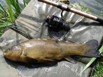

```python
path_tench = path/'val'/'n01440764'

img_path = path_tench.ls()[0]

img = PIL.Image.open(img_path); img
```

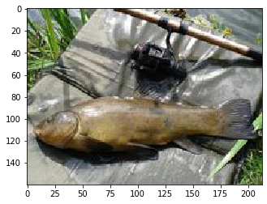

```python
plt.imshow(img)
```

```python
import numpy

imga = numpy.array(img); imga.shape
```

```
(160, 213, 3)
```

By opening our image in Numpy we can see its simply a 3 dimensional array of ints between 0 and 255.

```python
imga[:10, :10, 0]
```

```
array([[126, 127, 136, 150, ..., 172, 180, 171, 107],
       [130, 125, 129, 143, ..., 162, 162, 142, 161],
       [120, 119, 124, 132, ..., 143, 145, 153, 187],
       [114, 122, 129, 129, ..., 132, 142, 175, 166],
       ...,
       [153, 149, 141, 131, ..., 128, 122, 136, 148],
       [136, 150, 157, 144, ..., 131, 138, 154, 130],
       [ 57, 141, 165, 155, ..., 128, 145, 135, 140],
       [ 42,  80, 145, 137, ..., 142, 138, 138, 131]], dtype=uint8)
```

```python
#export
image_extension = set(k for k,v in mimetypes.types_map.items() if v.startswith('image'))
```

Setify is handy for eliminating duplicate elements:

```python
#export
def setify(x): return x if isinstance(x, set) else set(listify(x))
```

```python
setify(['a','b','a'])
```

```
{'a', 'b'}
```

```python
test_eq({'a','a','b'}, setify(['a','a','b']))
test_eq({'a',1}, setify(['a',1]))
```

`_get_files` will do the heavy lifting of collecting the specific files we are after.

It is passed a path to a folder, files in that folder, and an optional list of extensions. It then filters the filenames in that folder according to the extensions or if not extensions then it just excludes system files starting with '.':

```python
#export
def _get_files(p, fs, extensions=None):
    p = Path(p)
    # path / filename  if it does not start with a '.' and (no extensions are given OR the suffix is in extensions)
    res = [p/f for f in fs if not f.startswith('.') and ((not extensions) or f'.{f.split(".")[-1].lower()}' in extensions)]
    return res
```

We can quickly scan a diretory using the built in `os.scandir` which returns a list of filenames in that directory:

```python
fs = [o.name for o in os.scandir(path_tench)]
t = _get_files(path_tench, fs, image_extension)
fs[:3]
```

```
['ILSVRC2012_val_00009111.JPEG',
 'ILSVRC2012_val_00009191.JPEG',
 'ILSVRC2012_val_00017472.JPEG']
```

And our `_get_files` function will return the full path name of whatever files in that folder meet the defined conditions:

```python
t[:3]
```

```
[WindowsPath('D:/_DATA/fastai/data/imagenette2-160/val/n01440764/ILSVRC2012_val_00009111.JPEG'),
 WindowsPath('D:/_DATA/fastai/data/imagenette2-160/val/n01440764/ILSVRC2012_val_00009191.JPEG'),
 WindowsPath('D:/_DATA/fastai/data/imagenette2-160/val/n01440764/ILSVRC2012_val_00017472.JPEG')]
```

Now let's write a recursive function that will go through a given folder as well as its subfolders and return a list of image files:

```python
#export
def get_files(path, extensions=None, recurse=False, include=None):
    path = Path(path)
    extensions = setify(extensions)
    extensions = {e.lower() for e in extensions}

    if recurse:
        res = []
        #dirpath, dirnames, filenames
        for i,(p,d,f) in enumerate(os.walk(path)):
            if include is not None and i==0:
                d[:] = [o for o in d if o in include]
            else:
                d[:] = [o for o in d if not o.startswith('.')]
            res += _get_files(p, f, extensions)
        return res

    else:
        f = [o.name for o in os.scandir(path) if o.is_file()]
        return _get_files(path, f, extensions=extensions)
```

```python
get_files(path_tench, extensions=image_extension)[:3]
```

```
[WindowsPath('D:/_DATA/fastai/data/imagenette2-160/val/n01440764/ILSVRC2012_val_00009111.JPEG'),
 WindowsPath('D:/_DATA/fastai/data/imagenette2-160/val/n01440764/ILSVRC2012_val_00009191.JPEG'),
 WindowsPath('D:/_DATA/fastai/data/imagenette2-160/val/n01440764/ILSVRC2012_val_00017472.JPEG')]
```

But if we just give it our original `path` we'll need it to recursively go through each subfolder:

```python
get_files(path, extensions=image_extension, recurse=True)[:3]
```

```
[WindowsPath('D:/_DATA/fastai/data/imagenette2-160/train/n01440764/ILSVRC2012_val_00000293.JPEG'),
 WindowsPath('D:/_DATA/fastai/data/imagenette2-160/train/n01440764/ILSVRC2012_val_00002138.JPEG'),
 WindowsPath('D:/_DATA/fastai/data/imagenette2-160/train/n01440764/ILSVRC2012_val_00003014.JPEG')]
```

```python
all_imgs = get_files(path, extensions=image_extension, recurse=True)
```

```python
len(all_imgs)
```

```
13394
```

```python
%timeit get_files(path, image_extension, recurse=True)
```

```
59.8 ms ± 2.55 ms per loop (mean ± std. dev. of 7 runs, 10 loops each)
```

### ImageList

Now we can make an `ImageList` by inheriting from `ItemList` and defining how we want to get the files.

We just need two methods:

1. `from_files`: is a classmethod and will be used to instantiate an ImageList (ItemList) by calling `get_files`
2. `get`: opens the filename passed it to it.

`@classmethod`: Python only allows one **init** method per class. Using class methods it’s possible to add as many alternative constructors as necessary. Here we are using `from_files` as the method for supplying the items for the `ItemList`. It allows us to define unique constructors.

```python
#export
class ImageList(ItemList):
    @classmethod
    def from_files(cls, path, extensions=None, recurse=True, include=None, **kwargs):
        if extensions is None: extensions = image_extension
        return cls(get_files(path, extensions, recurse=recurse, include=None), path, **kwargs)

    def get(self, fn): return PIL.Image.open(fn)
```

Now we can use the `ImageList` class and instantiate it with `from_files` which collects the image filenames.

```python
il = ImageList.from_files(path)
```

And using the `__getitem__` we can open and image:

```python
il[0]
```

### Transform: Convert RGB

Transforms aren't only used for data augmentation. To allow total flexibility, `ImageList` returns the raw PIL image. The first thing is to convert it to 'RGB' (or something else).

Transforms only need to be functions that take an element of the `ItemList` and transform it.

If they need state, they can be defined as a class. Also, having them as a class allows to define an `_order` attribute (default 0) that is used to sort the transforms.

```python
#export
class Transform():
    _order = 0
```

Now let's make a Transformer class which converts an image to RGB:

```python
#export
class MakeRGB(Transform):
    def __call__(self, x): return x.convert('RGB')
```

But we can also just do this with a function and add a `_order` attribute:

```python
#export
def make_rgb(x):
    return x.convert('RGB')

make_rgb._order = 0
```

Let's make our `ImageList` again and pass our convert transform:

```python
il = ImageList.from_files(path, tfms=make_rgb)
```

And our `__repr__` gives us the number of items and the first ten:

```python
il
```

```
ImageList has (13394 items)
 [WindowsPath('D:/_DATA/fastai/data/imagenette2-160/train/n01440764/ILSVRC2012_val_00000293.JPEG'), WindowsPath('D:/_DATA/fastai/data/imagenette2-160/train/n01440764/ILSVRC2012_val_00002138.JPEG'), WindowsPath('D:/_DATA/fastai/data/imagenette2-160/train/n01440764/ILSVRC2012_val_00003014.JPEG'), Wind…
Path: D:\_DATA\fastai\data\imagenette2-160
```

```python
il[:1]
```

```
[<PIL.Image.Image image mode=RGB size=213x160 at 0x297BC848070>]
```

## Block 2: split data

There are numerous ways the training and validation might be separated.

In most cases, when not dealing with public datasets, we'll need to write a function that can randomly separate a specific percentage of the data.

We'll start with a function that will solve our problem of having the training and validation split into separate folders and then build a general class that can take other functions to make the split.

```python
path.ls()
```

```
[WindowsPath('D:/_DATA/fastai/data/imagenette2-160/train'),
 WindowsPath('D:/_DATA/fastai/data/imagenette2-160/val')]
```

```python
fn = il.items[0]; fn
```

```
WindowsPath('D:/_DATA/fastai/data/imagenette2-160/train/n01440764/ILSVRC2012_val_00000293.JPEG')
```

The items in our `ImageList` are Paths so we can see the dirname easily.

Then we can call `parent` twice to get to the train folder.

```python
fn.parent.parent.as_posix().split('/')[-1]
```

```
'train'
```

```python
#export
def grandparent_splitter(fn, train_name="train", valid_name="valid"):
    folder = fn.parent.parent.as_posix().split('/')[-1]
    return True if folder == train_name else False if folder == valid_name else None

def split_by_func(items, f):
    mask = [f(o) for o in items]
    fal = [o for o, m in zip(items, mask) if m==False]
    tru = [o for o, m in zip(items, mask) if m==True]
    return tru, fal
```

### `SplitData` class

Now that have a function for our dataet that can determine which files belong to what set for a given path let's make a `SplitData` class that can hold the training and validation set and be instantiated by a classmethod. In this case our class method instantiates it using `split_by_func`:

```python
#export
class SplitData():
    def __init__(self, train, valid):
        self.train = train
        self.valid = valid

    def __getattr__(self, k):
        return getattr(self.train, k)

    def __setstate__(self, data:Any):
        self.__dict__.update(data)

    @classmethod
    def split_by_func(cls, il, f):
        lists = map(il.new, split_by_func(il.items, f))
        return cls(*lists)

    def __repr__(self):
        return f'{self.__class__.__name__}\nTrain: {self.train}\nValid: {self.valid}\n'
```

Make a `splitter` function for our imagenette dataset:

```python
splitter = partial(grandparent_splitter, valid_name='val')
```

```python
train, valid = split_by_func(il.items, splitter)
```

```python
len(train),len(valid)
```

```
(9469, 3925)
```

```python
sd = SplitData.split_by_func(il, splitter); sd
```

```
SplitData
Train: ImageList has (9469 items)
 [WindowsPath('D:/_DATA/fastai/data/imagenette2-160/train/n01440764/ILSVRC2012_val_00000293.JPEG'), WindowsPath('D:/_DATA/fastai/data/imagenette2-160/train/n01440764/ILSVRC2012_val_00002138.JPEG'), WindowsPath('D:/_DATA/fastai/data/imagenette2-160/train/n01440764/ILSVRC2012_val_00003014.JPEG'), Wind…
Path: D:\_DATA\fastai\data\imagenette2-160
Valid: ImageList has (3925 items)
 [WindowsPath('D:/_DATA/fastai/data/imagenette2-160/val/n01440764/ILSVRC2012_val_00009111.JPEG'), WindowsPath('D:/_DATA/fastai/data/imagenette2-160/val/n01440764/ILSVRC2012_val_00009191.JPEG'), WindowsPath('D:/_DATA/fastai/data/imagenette2-160/val/n01440764/ILSVRC2012_val_00017472.JPEG'), WindowsPat…
Path: D:\_DATA\fastai\data\imagenette2-160
```

```python
sd.train[0]
```

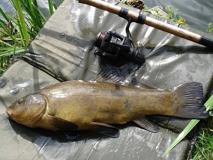

```python
sd.valid[0]
```

## Processors

A *Processor* is a transformation that is applied to all the inputs **once** at initialization, with some *state* computed on the training set that is then applied without modification on the validation set (and maybe the test set or at inference time on a single item).

Types of Processors:

- **NLP:** for processing texts to **tokenize**, then **numericalize** them. We want the validation set to be numericalized with exactly the same vocabulary as the training set.
- **Tabular Data:** where we want to **fill missing values** with (for instance) the median computed on the training set. That statistic is stored in the inner state of the *Processor* and applied on the validation set.
- **convert label strings to numbers** in a consistent and reproducible way. So we create a list of possible labels in the training set, and then convert our labels to numbers based on this *vocab*.

This is the base `Processor` class that does not really do anything. It has an instance method called `process` that just returns whatever it is given.

```python
#export
class Processor():
    def process(self, items):
        return items
```

### `CategoryProcessor`

Now in order to get labels for our image classification task we'll need a Processor is able to find and hold the categories it finds in the training set.

We'll write a function called `uniqueify` that will return an ordered list of unique items from an iterable. An `OrderedDict` is simply a dictionary that remembers insertion order.

```python
#export
from collections import OrderedDict

def uniqueify(x, sort=False):
    res = list(OrderedDict.fromkeys(x).keys())
    if sort: res.sort()
    return res
```

```python
list(OrderedDict.fromkeys([2,1,1,3]).keys())
```

```
[2, 1, 3]
```

```python
its = ['A','A','C','D','D']
```

```python
objs = list(OrderedDict.fromkeys(its).keys()); objs
```

```
['A', 'C', 'D']
```

```python
{v:k for k,v in enumerate(objs)}
```

```
{'A': 0, 'C': 1, 'D': 2}
```

Now the main `CategoryProcesser` class.

This processor will be able to handle two types of reference:

- Given an 'item' return an integer representing the category
- Given an 'idx' (integer or list of ints) return corresponding category label(s)

```python
#export
class CategoryProcesser(Processor):
    def __init__(self):
        self.vocab = None #this is the state, a list of unique objs

    def __call__(self, items):
        if self.vocab is None:
            self.vocab = uniqueify(items)
            self.otoi = {v:k for k,v in enumerate(self.vocab)} # obj:int from 0 to n
        return [self.proc1(o) for o in items]

    def proc1(self, item):
        return self.otoi[item]

    def deprocess(self, idxs):
        assert self.vocab is not None
        return [self.deproc1(idx) for idx in idxs]

    def deproc1(self, idx):
        return self.vocab[idx]
```

```python
cp = CategoryProcesser()

assert cp.vocab == None
```

```python
cp(its)
```

```
[0, 0, 1, 2, 2]
```

```python
cp.vocab
```

```
['A', 'C', 'D']
```

```python
cp.vocab[0]
```

```
'A'
```

## Block 3: labelling

For our labelling block we need to map from whatever type of label our training set has (whether a string, int, or float) to a $y$ tensor that our model can understand and calculate the loss on.

When doing classification our categories are mutually exclusive, so the set of possible labels is determined on the training set and then applied to the validation set. This ensures our $x, y$ mapping is the same for both.

To accomplish this we'll need a *Processor*.

### `LabeledData` Class

```python
#export
def parent_labeler(fn):
    return fn.parent.name

def _label_by_func(ds, f, cls=ItemList):
    return cls([f(o) for o in ds.items], path=ds.path)
```

```python
#export
class LabeledData():

    def process(self, il, proc):
        return il.new(compose(il.items, proc))

    def __init__(self, x, y, proc_x =None, proc_y=None):
        self.x = self.process(x, proc_x)
        self.y = self.process(y, proc_y)
        self.proc_x = proc_x
        self.proc_y = proc_y


    def __repr__(self):
        return f'{self.__class__.__name__}\nx: {self.x}\ny: {self.y}\n'

    def __getitem__(self, idx):
        return self.x[idx], self.y[idx]

    def __len__(self):
        return len(self.x)

    def x_obj(self, idx):
        return self.obj(self.x, idx, self.proc_x)

    def y_obj(self, idx):
        return self.obj(self.y, idx, self.proc_y)

    # method to
    def obj(self, items, idx, procs):
        isint = isinstance(idx, int) or (isinstance(idx, torch.LongTensor) and not idx.ndim)
        item = items[idx]
        for proc in reversed(listify(procs)):
            item = proc.deproc1(item) if isint else proc.deprocess(item)
        return item

    @classmethod
    def label_by_func(cls, il, f, proc_x=None, proc_y=None):
        return cls(il, _label_by_func(il,f), proc_x=proc_x, proc_y=proc_y)
```

```python
#export
def label_by_func(sd, f, proc_x=None, proc_y=None):
    train = LabeledData.label_by_func(sd.train, f, proc_x=proc_x, proc_y=proc_y)
    valid = LabeledData.label_by_func(sd.valid, f, proc_x=proc_x, proc_y=proc_y)
    return SplitData(train, valid)
```

```python
ll = label_by_func(sd, parent_labeler, proc_y=CategoryProcesser())
```

```python
ll
```

```
SplitData
Train: LabeledData
x: ImageList has (9469 items)
 [WindowsPath('D:/_DATA/fastai/data/imagenette2-160/train/n01440764/ILSVRC2012_val_00000293.JPEG'), WindowsPath('D:/_DATA/fastai/data/imagenette2-160/train/n01440764/ILSVRC2012_val_00002138.JPEG'), WindowsPath('D:/_DATA/fastai/data/imagenette2-160/train/n01440764/ILSVRC2012_val_00003014.JPEG'), Wind…
Path: D:\_DATA\fastai\data\imagenette2-160
y: ItemList has (9469 items)
 [0, 0, 0, 0, 0, 0, 0, 0, 0, 0...]
Path: D:\_DATA\fastai\data\imagenette2-160

Valid: LabeledData
x: ImageList has (3925 items)
 [WindowsPath('D:/_DATA/fastai/data/imagenette2-160/val/n01440764/ILSVRC2012_val_00009111.JPEG'), WindowsPath('D:/_DATA/fastai/data/imagenette2-160/val/n01440764/ILSVRC2012_val_00009191.JPEG'), WindowsPath('D:/_DATA/fastai/data/imagenette2-160/val/n01440764/ILSVRC2012_val_00017472.JPEG'), WindowsPat…
Path: D:\_DATA\fastai\data\imagenette2-160
y: ItemList has (3925 items)
 [0, 0, 0, 0, 0, 0, 0, 0, 0, 0...]
Path: D:\_DATA\fastai\data\imagenette2-160
```

```python
assert ll.train.proc_y == ll.valid.proc_y
```

```python
ll.__class__
```

```
__main__.SplitData
```

```python
ll.train.__class__
```

```
__main__.LabeledData
```

```python
ll.train.x.__class__
```

```
__main__.ImageList
```

```python
ll.train.x.items.__class__
```

```
list
```

```python
ll.train.y.items[0], ll.train.y_obj(0)
```

```
(0, 'n01440764')
```

```python
ll.train.x[0]
```

## Transforms

What are transforms?

What is the general pattern?

What transforms do we need for images specifically?

### Resize transform

Our first transform is easy - just resize each image to a given size.

```python
ll.train[0][0]
```

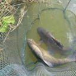

```python
ll.train[0][0].resize((128,128))
```

```python
#export
class ResizeFixed(Transform):
    _order = 10
    def __init__(self, size):
        if isinstance(size, int):
            size=(size, size)
        self.size = size

    def __call__(self, item):
        return item.resize(self.size, PIL.Image.BILINEAR)
```

### `to_byte_tensor` transform

Why to byte?

```python
#export
def to_byte_tensor(item):
    res = torch.ByteTensor(torch.ByteStorage.from_buffer(item.tobytes()))
    w,h = item.size
    return res.view(h,w, -1).permute(2,0,1)

to_byte_tensor._order = 20
```

```python
to_byte_tensor(ll.train[0][0]).shape
```

```
torch.Size([3, 160, 213])
```

### `to_float_tensor` transform

```python
#export
def to_float_tensor(item):
    return item.float().div_(255.)

to_float_tensor._order=30
```

```python
to_float_tensor(to_byte_tensor(ll.train[0][0]))[:2]
```

```
tensor([[[0.4510, 0.6000, 0.7373,  ..., 0.6745, 0.7725, 0.7529],
         [0.5843, 0.7451, 0.8157,  ..., 0.6314, 0.7098, 0.6784],
         [0.7922, 0.6706, 0.5765,  ..., 0.5765, 0.6510, 0.6235],
         ...,
         [0.5922, 0.4980, 0.4667,  ..., 0.6235, 0.6196, 0.5529],
         [0.5255, 0.5059, 0.4784,  ..., 0.7098, 0.5059, 0.3922],
         [0.3961, 0.4314, 0.4745,  ..., 0.5294, 0.3608, 0.3529]],

        [[0.4235, 0.5686, 0.7020,  ..., 0.7255, 0.8235, 0.8039],
         [0.5569, 0.7137, 0.7882,  ..., 0.6824, 0.7608, 0.7294],
         [0.7725, 0.6471, 0.5490,  ..., 0.6275, 0.7020, 0.6745],
         ...,
         [0.7020, 0.6078, 0.5765,  ..., 0.6706, 0.6667, 0.6000],
         [0.6275, 0.6078, 0.5804,  ..., 0.7569, 0.5529, 0.4392],
         [0.4980, 0.5333, 0.5765,  ..., 0.5843, 0.4157, 0.4078]]])
```

It's useful to have a show image function

```python
#export
def show_image(im, figsize=(3,3)):
    plt.figure(figsize=figsize)
    plt.axis('off')
    plt.imshow(im.permute(1,2,0))
```

## Full DataBlock API

Now to put all of following back together:

```python
tfms = [make_rgb, ResizeFixed(128), to_byte_tensor, to_float_tensor]

il = ImageList.from_files(path, tfms=tfms)
sd = SplitData.split_by_func(il, splitter)
ll = label_by_func(sd, parent_labeler, proc_y=CategoryProcesser())
```

```python
x, y = ll.train[0]
```

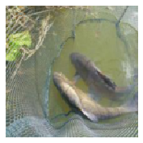

```python
show_image(x)
```

# Modeling

### DataBunch

Now we have our datasets we can put them into a modified `DataBunch` object:

```python
bs = 64
```

```python
train_dl, valid_dl = get_dls(ll.train, ll.valid, bs)
```

```python
x, y = next(iter(train_dl))
x.shape
```

```
torch.Size([64, 3, 128, 128])
```

We can now see the first image in the batch.

This image has had transforms applied to it:

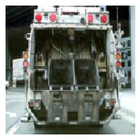

```python
show_image(x[0])
```

```python
ll.train.proc_y.vocab[y[0]]
```

```
'n03417042'
```

```python
y
```

```
tensor([6, 7, 0, 7, 9, 8, 5, 9, 2, 7, 2, 2, 2, 2, 8, 4, 7, 9, 6, 9, 4, 2, 5, 3,
        6, 3, 0, 3, 7, 4, 0, 6, 0, 0, 9, 0, 8, 5, 9, 9, 1, 6, 7, 4, 7, 7, 3, 9,
        7, 3, 1, 4, 3, 0, 3, 7, 7, 5, 4, 7, 1, 8, 7, 4])
```

```python
#export
class DataBunch():
    def __init__(self, train_dl, valid_dl, c_in=None, c_out=None):
        self.train_dl, self.valid_dl = train_dl, valid_dl
        self.c_in, self.c_out = c_in, c_out

    @property
    def train_ds(self): return self.train_dl.dataset

    @property
    def valid_ds(self): return self.valid_dl.dataset
```

And a helper function to go from the `Splitdata` to `DataBunch`:

```python
#export
def databunchify(sd, bs, c_in=None, c_out=None, **kwargs):
    train, valid = get_dls(sd.train, sd.valid, bs=bs, **kwargs)
    return DataBunch(train, valid, c_in=c_in, c_out=c_out)

SplitData.to_databunch = databunchify
```

Full summary of collecting data to DataBunch:

```python
path = datasets.untar_data(datasets.URLs.IMAGENETTE_160) # downloads and returns a path to folder
tfms = [make_rgb, ResizeFixed(128), to_byte_tensor, to_float_tensor] # transforms to be applied to images

il = ImageList.from_files(path, tfms=tfms) # Imagelist from files
sd = SplitData.split_by_func(il, partial(grandparent_splitter, valid_name="val")) # Splitdata by function
ll = label_by_func(sd, parent_labeler, proc_y=CategoryProcesser()) # label the data by parent folder
data = ll.to_databunch(bs, c_in=3, c_out=10)
```

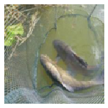

```python
show_image(data.train_ds[0][0])
```

### Normalization Callback

```python
callbacks = [partial(AvgStatsCallback, accuracy), CudaCallback]
```

Finding the mean and standard deviation of a batch to normalize our data.

```python
m = x.mean((0,2,3)).cuda() # mean of each channel
s = x.std((0,2,3)).cuda() # std of each channel
m, s
```

```
(tensor([0.4419, 0.4332, 0.4166], device='cuda:0'),
 tensor([0.2732, 0.2724, 0.2971], device='cuda:0'))
```

```python
#export
def normalize_chan(x, mean, std):
    return (x-mean[...,None,None]) / std[...,None,None]

_m = tensor([0.4419, 0.4332, 0.4166])
_s = tensor([0.2732, 0.2724, 0.2971])

norm_imagenette = partial(normalize_chan, mean=_m.cuda(), std=_s.cuda())
```

```python
callbacks.append(partial(BatchTransformXCallback, norm_imagenette))
```

```python
nb_auto_export()
```